# The mosaic Package: Helping Students to ‘Think with Data’ Using R

Randall Pruim

Calvin College

Daniel T Kaplan

Macalester College

Nicholas J Horton

Amherst College

2017-05-10

Abstract

The mosaic package provides a simplified and systematic introduction to the core functionality related to descriptive statistics, visualization, modeling, and simulation-based inference required in first and second courses in statistics. This introduction to the package describes some of the guiding principles behind the design of the package and provides illustrative examples of several of the most important functions it implements. These can be combined to help students “think with data" using R in their early course work, starting with simple, yet powerful, declarative commands.

# Motivation

In order to make sense of rich data that is increasingly available, students need computational tools and facility for data management, exploratory analysis, visualization, and modeling (e.g., (Nolan and Lang 2010; Horton, Baumer, and Wickham 2015; Horton and Hardin 2015; Ridgway 2016)). To extract useful information from the complex systems that generate this rich data, students should learn to “think with data” (in the phrase coined by Diane Lambert of Google): using previous results from data to drive statistical investigations and to inform the choice of analysis and presentation possibilities.

Yet many students enter statistics courses with little or no computational experience. Software such as R that encompass the tools for thinking with data are sometimes regarded as off-putting and inaccessible to students. With the *mosaic* package, we have sought to remove unnecessary difficulty in the use of R by students. Our students have demonstrated that it is feasible to integrate computing into our curricula early and often, in a way that provides students with success, confidence, and room to grow.

# A guiding principle: Less volume, more creativity

The [*mosaic*](https://CRAN.R-project.org/package=mosaic) (Pruim, Kaplan, and Horton 2016) package reflects attempts by each of the authors to make the power of R accessible and rewarding to students, especially in the context of undergraduate statistics courses, and, in one case, also in calculus. One of the guiding principles behind the development of the *mosaic* package has been “Less volume, more creativity.” By “less volume,” we mean reducing the cognitive load involved in using R. By “more creativity” we mean two things. First, we want to provide access to R tools in a way that fosters choices and decision making by students. Such decisions might be about modes of analysis or visualization or about the variables and covariates to consider when exploring relationships with data. Second, we want to encourage students to creatively engage with statistical inference methods via simulation techniques such as randomization and resampling with data analysis and presentation.

Our route to “less volume” is to provide a set of three command templates — formulas, functions, and extractors — that standardize usage across many tasks and that highlight the connections between graphical summaries, numerical summaries, models, and inference. The templates themselves are designed to be consistent and concise. Consistency enables a student to generalize from a specific task to a wide set of possibilities. Conciseness means avoiding unnecessary elements so that the essential inputs to a computation are made clear and organized according a syntax that makes the role of each input understandable and predictable.

# The importance of multivariate thinking

The importance of giving students experience with multivariable thinking is a point of emphasis in the newly revised ASA Guidelines for assessment and instruction in statistics education (GAISE) report (ASA GAISE College working group et al. 2016):

> When students leave an introductory course, they will likely encounter situations within their own fields of study in which multiple variables relate to one another in intricate ways. We should prepare our students for challenging questions that require investigating and exploring relationships among more than two variables. (page 16)

> Perhaps the best place to start is to consider how a third variable can change our understanding of the relationship between two variables. … Simple approaches (such as stratification) can help to discern the true associations. Stratification requires no advanced methods, nor even any inference, though some instructors may incorporate other related concepts and approaches such as multiple regression. These examples can help to introduce students to techniques for assessing relationships between more than two variables. Including one or more multivariable examples early in an introductory statistics course may help to prepare students to deal with more than one or two variables at a time… (page 34)

The *mosaic* package helps support these goals by providing a unified framework within which multivariable graphical and numerical summaries are easy to create, even for beginners.

# The formula template

Our most important template makes use of a “formula interface” that has long been used by familiar R functions like `t.test()`, `lm()`, and the plotting functions in [*lattice*](https://CRAN.R-project.org/package=lattice) (Sarkar 2008). Our initial example uses the `Births78` data set, which records the number of live births in the United States for each day of 1978.

```r
library(mosaic)
head(Births78, 3)
```

```r
##         date births dayofyear wday
## 1 1978-01-01   7701         1  Sun
## 2 1978-01-02   7527         2  Mon
## 3 1978-01-03   8825         3 Tues
```

We will use this example to illustrate the difference between using a consistent interface across graphical and numerical summaries and the limitations of basic R functions that do *not* use formulas.

We typically introduce the formula template in the context of exploring the relationship between two variables, e.g.

```r
goal( y ~ x, data = MyData, ... )    # pseudo-code for the formula template
```

We teach students to read `y ~ x` as “y wiggle x” and to interpret this in any of several essentially equivalent forms: “`y` broken down by `x`”; “`y` modeled by `x`”; “`y` explained by `x`”; “`y` depends on `x`”; or “`y` accounted for by `x`.” For graphics, it’s reasonable to read the formula as “`y` vs. `x`”, which is exactly the convention used for coordinate axes. But “`y` vs. `x`” does not as clearly convey the asymmetry of the other forms.

This template is not original to [*mosaic*](https://CRAN.R-project.org/package=mosaic). Those familiar with R will recognize this as the template already used by functions such as `lm()` and the *lattice* plotting functions. The *mosaic* package extends this template to numerical summaries and provides some additional features for plotting and fitting models, thereby bringing all of these activities into a consistent, unified appraoch.

Our first plot of the `Births78` data might be a scatterplot showing how the number of births depends on the date. Using our template and the *lattice* function `xyplot()`, we can create this with the following simple command by filling in the slots in our formula template.

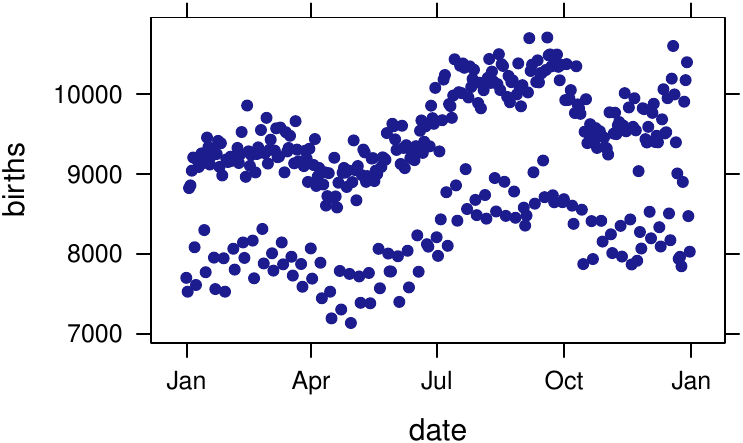

```r
library(lattice)
xyplot(births ~ date, data = Births78)
```

The scatterplot reveals some interesting patterns over the course of the year. Getting students to make conjectures about possible explanations can help diagnose how well students understand the information displayed in the scatterplot. (Students who suggest that there are two parallel waves because more children are born at certain times of the year reveal that they are misunderstanding this plot, for example.)

One reasonable conjecture for the two parallel waves is a weekend effect. We would like our students to be able to explore this conjecture graphically, numerically, and (eventually) with statistical models. We might begin by creating side-by-side boxplots. The *lattice* package makes this as easy as the scatterplot above. We simply replace `xyplot()` with `bwplot()` because we have a different goal. If we prefer, we can also reverse the order of the variables in the formula to flip which axis is used for which purpose.

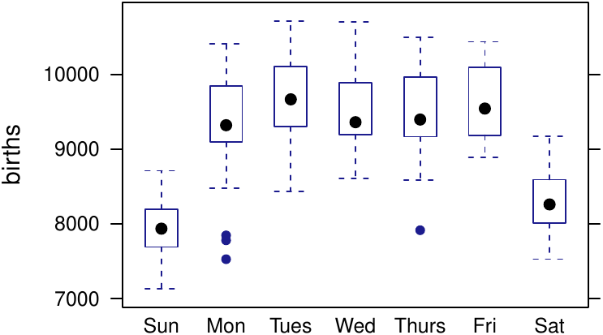

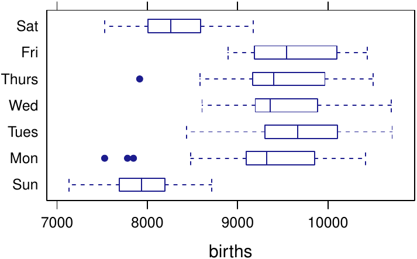

```r
bwplot(births ~ wday, data = Births78)
bwplot(wday ~ births, data = Births78, pch = "|")  # a more common way to show median
```

To quantify the differences observed in these plots, we might like to compute the mean (or median) number of births for each weekday. Basic statistical calculations can be admirably concise in R. For instance, the mean number of daily births (over all days) can be calculated with

```r
mean(Births78$births)    # or use with() instead of $
```

```r
## [1] 9132
```

Unfortunately, this is a dead end when it comes to thinking with data. How, for instance, does one explore whether there is a day-of-the-week component to the number of births? Here are a few conventional approaches in R to such a calculation.

```r
aggregate(Births78$births, FUN = mean, by = list(Births78$wday))
```

or, equivalently,

```r
with(Births78, aggregate(births, FUN = mean, by = list(wday)))
```

```r
##   Group.1    x
## 1     Sun 7951
## 2     Mon 9371
## 3    Tues 9709
## 4     Wed 9498
## 5   Thurs 9484
## 6     Fri 9626
## 7     Sat 8309
```

or, alternatively,

```r
with(Births78, tapply(births, wday, mean))
```

```r
##   Sun   Mon  Tues   Wed Thurs   Fri   Sat
##  7951  9371  9709  9498  9484  9626  8309
```

None of these show any similarity to `mean(Births78$births)` or to the commands that created the plots that generated our conjecture. All of them bury `mean()` in the center or at the end of the command and require additional structure like `aggregate()`, `tapply()`, lists, and nested parentheses. Even reading the commands is difficult.

The essential elements in each of these calculations are `mean()`, `Births78`, `births` and `wday`: We want to see how the mean number of births depends on the day of the week using data from 1978. The *mosaic* formula template for this calculation mirrors the template used to create plots in *lattice* and highlights these essential elements:

```r
library(mosaic)
mean(births ~ wday, data = Births78)
```

```r
##   Sun   Mon  Tues   Wed Thurs   Fri   Sat
##  7951  9371  9709  9498  9484  9626  8309
```

This form makes clear that the `mean()` is being calculated and that `Births78` holds the data. The relationship between the variables is specified by the formula. Most importantly, it is the same template that was used to create the plots that preceded it – we simply replace `bwplot()` or `xyplot()` with `mean()`.

Using the *mosaic* package, this same template extends to many other numerical summaries, e.g.,

```r
median(births ~ wday, data = Births78)
```

```r
##   Sun   Mon  Tues   Wed Thurs   Fri   Sat
##  7936  9321  9668  9362  9397  9544  8260
```

```r
sd(births ~ wday, data = Births78)
```

```r
##   Sun   Mon  Tues   Wed Thurs   Fri   Sat
##   410   608   527   461   551   488   390
```

```r
favstats(births ~ wday, data = Births78)
```

```r
##    wday  min   Q1 median    Q3   max mean  sd  n missing
## 1   Sun 7135 7691   7936  8196  8711 7951 410 53       0
## 2   Mon 7527 9097   9321  9838 10414 9371 608 52       0
## 3  Tues 8433 9304   9668 10084 10711 9709 527 52       0
## 4   Wed 8606 9196   9362  9880 10703 9498 461 52       0
## 5 Thurs 7915 9171   9397  9958 10499 9484 551 52       0
## 6   Fri 8892 9198   9544 10088 10438 9626 488 52       0
## 7   Sat 7527 8007   8260  8586  9170 8309 390 52       0
```

The *mosaic* package provides formula interfaces for `mean()`, `median()`, `sd()`, `var()`, `cor()`, `cov()`, `quantile()`, `max()`, `min()`, `range()`, `IQR()`, `iqr()`, `fivenum()`, `prod()`, and `sum()`. In each case we have been careful not to break behavior of the underlying functions from *base* and *stats*.

Model-building functions such as `lm()` and `glm()` also employ the same template:

```r
births.model <- lm(births ~ wday, data = Births78)
```

so early experience with graphical and numerical summaries prepares students for statistical modeling later in the course.

When working with categorical data, tabulation is an important technique. The `table()` function does not accept formulas and `xtabs()` uses formulas in a different way. The *mosaic* package provides a formula-template `tally()` function for counting categorical variables. We illustrate its use with another data set from [*mosaicData*](https://CRAN.R-project.org/package=mosaicData) (Pruim, Kaplan, and Horton, n.d.). `Whickham` contains data from a UK study that enrolled subjects in 1972–74 and conducted a follow-up 20 years later.

```r
tally(outcome ~ smoker, data = Whickham)
```

```r
##        smoker
## outcome  No Yes
##   Alive 502 443
##   Dead  230 139
```

```r
tally(outcome ~ smoker, data = Whickham, margins = TRUE)
```

```r
##        smoker
## outcome  No Yes
##   Alive 502 443
##   Dead  230 139
##   Total 732 582
```

```r
tally(outcome ~ smoker, data = Whickham, margins = TRUE, format = "proportion")
```

```r
##        smoker
## outcome    No   Yes
##   Alive 0.686 0.761
##   Dead  0.314 0.239
##   Total 1.000 1.000
```

Notice that in the final example, conditional proportions are calculated. The conditional probabilities were computed in a way that respects the asymmetric meaning of the formula `outcome ~ smoker`: using `smoker` to account for `outcome`. The probabilities indicate that smokers were more likely to be alive in the follow-up study. More on this in a moment.

The formula template can be extended to handle one variable or more than two variables, but for several reasons we recommend introducing it in the context of two-variable plots and numerical summaries. We offer this recommendation because (1) two-variable plots and numerical summaries are more “impressive” than one-variable plots and less likely to be something students can as readily do with tools they already know, (2) working with more than one variable from the start (correctly) suggests that the most interesting parts of statistics involve more than one variable (Wild et al. 2011), and (3) the formula syntax for a single variable makes more sense in the context of two-sided formulas than it does in isolation.

Formulas with a single variable correspond to situations where there is no “explanatory” variable to be included, for example in simple numerical summaries or depictions of the distribution of a variable.

```r
mean( ~ age, data = Whickham)
```

```r
## [1] 46.9
```

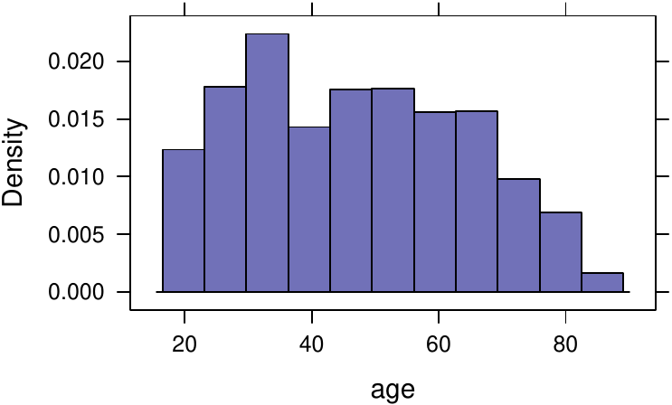

```r
histogram( ~ age, data = Whickham)
```

To some instructors, it seems more natural when there is no explanatory variable for the single variable to be on the left-hand side of `~`. But the R parser does not support this: a formula must have a right-hand side. Even if R allowed such formulas, the use of `y ~` would break the analogy to graphical summaries where a single variable is traditionally displayed on the $x$-axis, as in the histogram above.

The numerical summary functions provided by *mosaic* also allow formulas like `age ~ NULL` to signify there is no explanatory variable.

```r
mean( age ~ NULL, data = Whickham)
```

```r
## [1] 46.9
```

We don’t emphasize this form, however, since it is not supported by the *lattice* functions.

“Thinking with data” implies the ability to examine relationships among multiple variables. The formula template accomodates more than one variable on the right-hand side of the tilde, for instance:

```r
mean(age ~ smoker + outcome, data = Whickham)
```

```r
##  No.Alive Yes.Alive   No.Dead  Yes.Dead
##      40.0      40.1      67.6      59.2
```

The *lattice* package provides a number of ways to include additional variables in plots. Inclusion of in a formula, for example, specifies a variable to be used for defining subpanels (or facets).

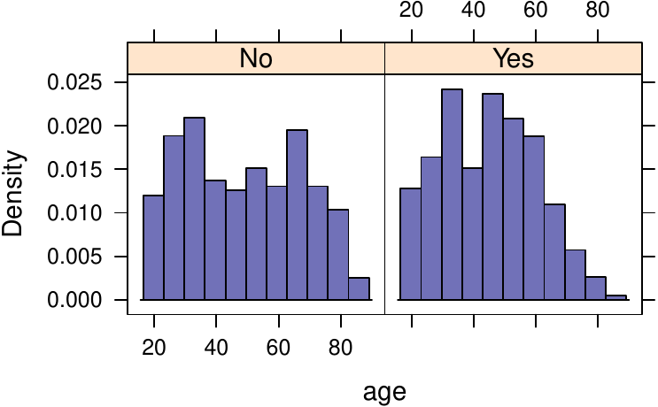

```r
histogram( ~ age | smoker, data = Whickham)
```

Another option is to overlay multiple layers in a plot; *lattice* does this via a `groups` argument.

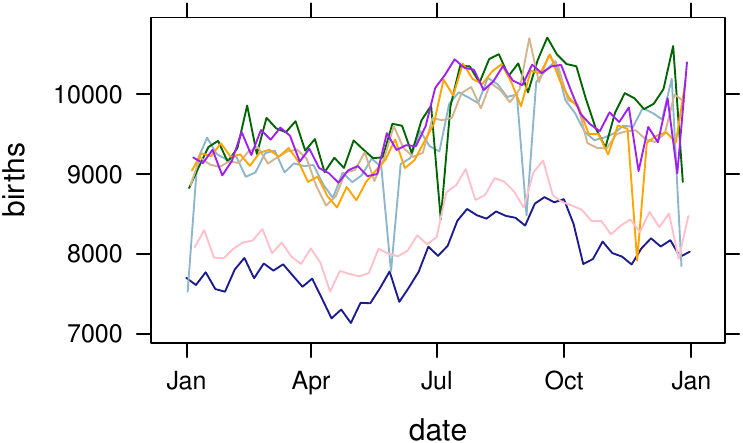

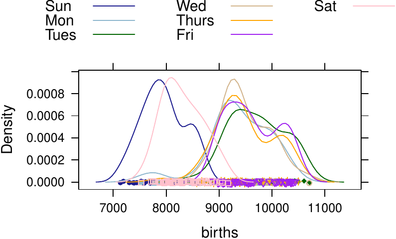

```r
xyplot(births ~ date, groups = wday, data = Births78, type = "l")
densityplot( ~ births, groups = wday, data = Births78, auto.key = list(columns = 3))
```

Each of these two plots shows a clear difference in the distribution of births on the two weekend days compared to the other five days of the week.

For ease in moving between plots and numerical summaries, *mosaic* functions such as `mean()` and `tally()` also accept this expanded syntax.

```r
mean( ~ age | smoker, data = Whickham)
```

```r
##   No  Yes
## 48.7 44.7
```

```r
mean( ~ births, groups = wday, data = Births78)
```

```r
##   Sun   Mon  Tues   Wed Thurs   Fri   Sat
##  7951  9371  9709  9498  9484  9626  8309
```

Notice that the mean age for smokers in the Whickham study is substantially lower than for the non-smokers, so an accurate comparison of survival rates must take age into account.

The formula template allows students to think about relationships between and among two or more variables and to test conjectures using graphical and numerical summaries. Having learned the formula interface to graphical and numerical summaries early on, new users are well prepared for modeling with `lm()`, `glm()`, and various “test” functions such as `t.test()` when the time comes. More importantly, they begin early to train their minds to ask questions of the form “How does this depend on that (and some other things)?”.

By emphasizing the formula template, each of the following commands can be viewed as instances of a common template, rather than as separate things to learn.

```r
bwplot(age ~ smoker, data = Whickham)     # standard function in lattice
  mean(age ~ smoker, data = Whickham)     # formula interface added in mosaic
    sd(age ~ smoker, data = Whickham)     # formula interface added in mosaic
    lm(age ~ smoker, data = Whickham)     # standard function in stats
```

Similarly, by adding additional formula interfaces to `t.test()`, `binom.test()`, and `prop.test()`, and adding some additional plot types, for one-variable situations we have

```r
       mean( ~ age, data = Whickham)      # formula interface added in mosaic
         sd( ~ age, data = Whickham)      # formula interface added in mosaic
   favstats( ~ age, data = Whickham)      # new function in mosaic
  histogram( ~ age, data = Whickham)      # standard function in lattice
     t.test( ~ age, data = Whickham)      # formula interface added in mosaic
 binom.test( ~ smoker, data = Whickham)   # formula interface added in mosaic
  prop.test( ~ smoker, data = Whickham)   # formula interface added in mosaic
```

Adding covariates to one- or two- variable graphical or numerical summaries fits readily into the template as well.

```r
     mean( ~ age | smoker, data = Whickham)   # formula interface added in mosaic
       sd( ~ age | smoker, data = Whickham)   # formula interface added in mosaic
histogram( ~ age | smoker, data = Whickham)   # standard lattice
   t.test( ~ age | smoker, data = Whickham)   # expanded formula interface in mosaic
```

While specifying the correct formula can produce some challenges for new users, clearly explaining the roles of each component for plotting, for numerical summaries, and for model fitting helps demystify the situation. Instructors have had students create and interpret bivariate and trivariate graphical displays on the first day of class (Wang, Rush, and Horton 2017). We have also found that explicit, early, low-stakes assessment of student mastery of the formula interface greatly improves student performance. A first quiz consisting of a single item (What is the formula template?) followed by one or two simple pencil-and-paper quizzes asking students to write the commands to recreate a handful of numerical and graphical summaries suffices.

# The model-function template

Modeling functions like `lm()` and `glm()` can fit a wide range of statistical models. But functions like `predict()` are challenging for new users (primarily because of the user must create a data frame in order to evaluate the model function on user-specified inputs), and constructing a useful graphical representation of a data set together with a logistic regression fit even more so. The *mosaic* functions `makeFun()`, `plotFun()`, and `plotModel()` make these tasks easier.

In particular, `makeFun()` extracts from a model object created by `lm()` or `glm()` a function that is a wrapper around `predict()` and can be used with standard function syntax that is familiar to students from the way functions are typically described in secondary school and in calculus. This wrapper around `predict()` is easier for beginners to use because (1) it returns a function to which inputs can be supplied without creating a data frame, (2) the resulting function returns values on the response scale by default, and (3) it back transforms a few common transformations of the response variable, including `log()` and `sqrt()` (and allows the user to provide a custom value to the `transformation` argument to handle other cases).

The functions extracted from models using `makeFun()` (and functions created in other ways) can be plotted with `plotFun()`. In the example below, we illustrate the use of `makeFun()` and `plotFun()` to compare linear and quadratic fits to the same data.

```r
cars.mod1 <- lm(dist ~ speed, data = cars)
cars.mod2 <- lm(dist ~ poly(speed,2), data = cars)
# extract functions for each model that compute distance from speed
cars.dist1 <- makeFun(cars.mod1)
cars.dist2 <- makeFun(cars.mod2)
# evaluate these functions as user-specified values of speed
cars.dist2(speed = 15)
```

```r
##    1
## 38.7
```

```r
cars.dist2(speed = 15, interval = "confidence")
```

```r
##    fit lwr  upr
## 1 38.7  33 44.3
```

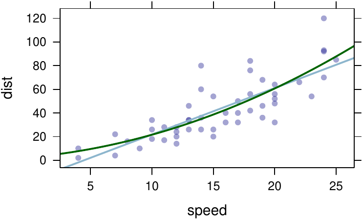

```r
# add plots of these functions to a scatter plot
xyplot(dist ~ speed, data = cars, alpha = 0.4)
plotFun(cars.dist1(speed) ~ speed, add = TRUE, col = 2, lwd = 2)
plotFun(cars.dist2(speed) ~ speed, add = TRUE, col = 3, lwd = 2)
```

For logistic regression, when the response is coded as a factor, we need to adjust things slightly when plotting because the model function returns values between 0 and 1, but 2-level factors are coded as 1 and 2 in R.

```r
smoker.mod <- glm(outcome ~ smoker + age, data = Whickham, family = binomial)
smoker.fun <- makeFun(smoker.mod)
smoker.fun(age = 60, smoker = "Yes")
```

```r
##     1
## 0.507
```

```r
smoker.fun(age = 60, smoker = "No")
```

```r
##     1
## 0.456
```

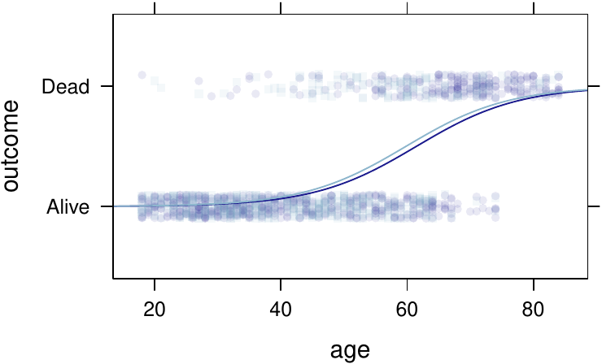

```r
xyplot(outcome ~ age, groups = smoker, data = Whickham, jitter.y = TRUE, alpha = 0.1)
plotFun(1 + smoker.fun(age, smoker = "No") ~ age, col = 1, add = TRUE)
plotFun(1 + smoker.fun(age, smoker = "Yes") ~ age, col = 2, add = TRUE)
```

When the response variable in the model is transformed, the `transformation` argument to `makeFun()` can be used to specify the back-transformation. For a few common transformations (e.g., `log()` and `sqrt()`), the value of `transformation` is determined automatically (by default).

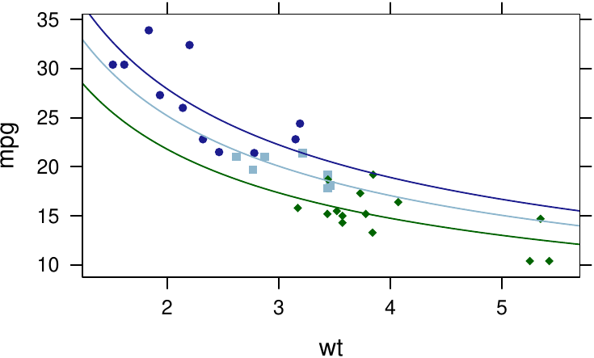

```r
mtcars.mod <- lm(log(mpg) ~ log(wt) + factor(cyl), data = mtcars)
mileage <- makeFun(mtcars.mod)
xyplot(mpg ~ wt, data = mtcars, groups = cyl)
plotFun(mileage(wt, cyl = 4) ~ wt, add = TRUE, col = 1)
plotFun(mileage(wt, cyl = 6) ~ wt, add = TRUE, col = 2)
plotFun(mileage(wt, cyl = 8) ~ wt, add = TRUE, col = 3)
```

For models with two quantitative predictors, `plotFun()` can create a contour plot. The following model explores how the average SAT score depends on the amount of money spent on education (in thousands of dollars per student) by a US State and the precent of students in that state who take the SAT exam.

```r
SAT.mod <- lm(sat ~ expend * frac, data = SAT)
msummary(SAT.mod)
```

```r
##             Estimate Std. Error t value Pr(>|t|)
## (Intercept) 1057.121     42.040   25.15  < 2e-16 ***
## expend         0.629      7.846    0.08    0.936
## frac          -4.232      0.818   -5.18  4.9e-06 ***
## expend:frac    0.237      0.135    1.75    0.087 .
##
## Residual standard error: 31.8 on 46 degrees of freedom
## Multiple R-squared:  0.831,  Adjusted R-squared:  0.82
## F-statistic: 75.2 on 3 and 46 DF,  p-value: <2e-16
```

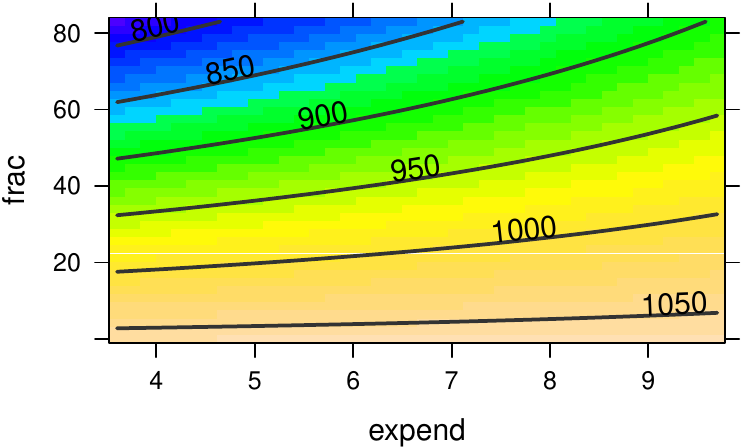

```r
sat.pred <- makeFun(SAT.mod)
plotFun(sat.pred(expend, frac) ~ expend + frac,
       expend.lim=c(3.6,9.7), frac.lim=c(0,83))
```

The `msummary()` function provides a terser summary of the model object than `summary()`. The plot shows that this model predicts performance on the exam to increase with increased expenditure and decreased participation in the exam. (In states with lower participation rates there is a selection bias toward stronger students who are seeking admission into out-of-state colleges and universities.) Furthermore, the effect of increased spending appears to be greater when a larger percent of the students take the exam. Interestingly, a simpler linear model that includes only expenditure as a predictor has a negative slope.

For many simple models, creating a plot can be even simpler using `plotModel()`, which also eliminates the need to manually adjust logistic regression plots when the response is a factor. For models with multiple predictors, we can supply a formula to indicate which predictor we prefer to have on the x-axis.

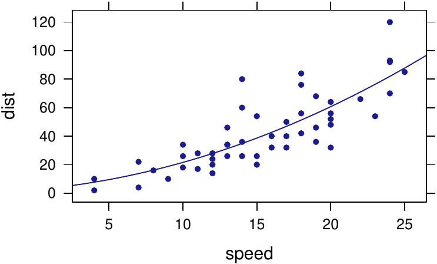

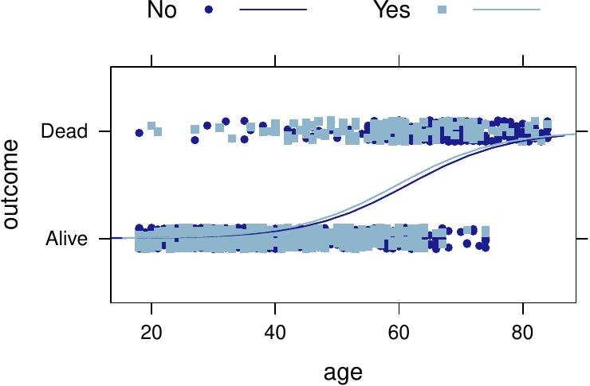

```r
plotModel(cars.mod2)
plotModel(smoker.mod, outcome ~ age, jitter.y = TRUE)
```

The `plotModel()` function can also simplify visualization of more complex models.

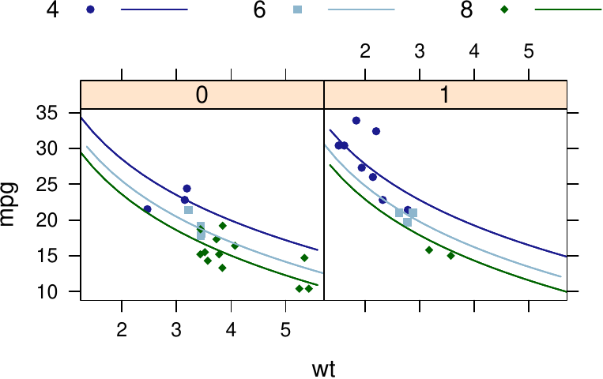

```r
mtcars.mod2 <- lm(mpg ~ log(wt) + factor(cyl) + factor(am), data = mtcars)
plotModel(mtcars.mod2, mpg ~ wt | factor(am))
```

# The extractor template

The use of `makeFun()` to create a function from a model illustrates another important template, the extractor template:

```r
object <- { some computation }
extractor(object)              # extract some information from object
```

R has many such extractors which summarize, display, or extract partial information from an object. The `print()`, `plot()`, and `summary()` functions are examples of extractors that can be applied to many types of objects. Other extractors, like `coef()`, `resid()`, and `fitted()` are designed to work with a much smaller set of objects. The *mosaic* package defines several extractors including those listed in Table 1.

Table 1: Extractors defined in the *mosaic* package.

| Extractor | Purpose |
| --- | --- |
| `makeFun()` | Extract a fitted function from a model. |
| `rsquared()` | Extract $r^2$ from a linear model. |
| `stat()` | Extract the test statistic from a hypothesis test. |
| `pval()` | Extract the p-value from a hypothesis test. |
| `confint()` | Extract the confidence interval from a hypothesis test. |
| `mplot()` | Create a plot from an object. |

```r
confint(t.test( ~ age, data = Whickham))      # works for any "htest" object
```

```r
##   mean of x lower upper level
## 1      46.9    46  47.9  0.95
```

```r
pval(t.test(age ~ smoker, data = Whickham))    # works for any "htest" object
```

```r
##  p.value
## 2.06e-05
```

```r
stat(t.test(age ~ smoker, data = Whickham))    # works for any "htest" object
```

```r
##    t
## 4.27
```

```r
rsquared(lm(age ~ smoker, data = Whickham))
```

```r
## [1] 0.0131
```

## The `mplot()` function

Like `plot()`, `mplot()` has many uses depending on the kind of input it receives. The two primary uses cases are creating diagnostic plots for lm and glm objects, and interactively creating data visualizations using the variables in a data frame.

Given a model object as its first argument, `mplot()` provides similar diagnostic plots to those produced via `plot()` but with two primary differences: the user may select to use either *lattice* or [*ggplot2*](https://CRAN.R-project.org/package=ggplot2) (Wickham 2009) graphics instead of base graphics, and an additional plot type is provided to visualize the confidence intervals for the coefficients of a regression model.

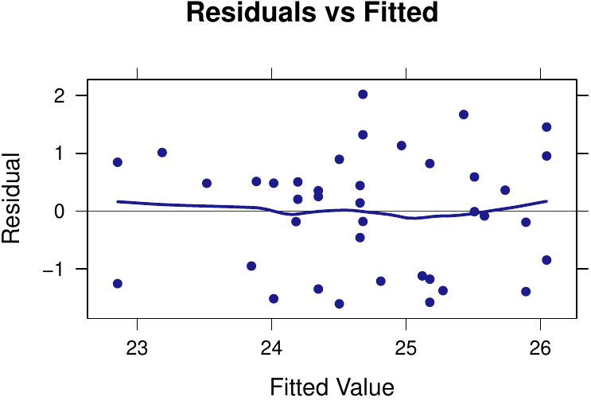

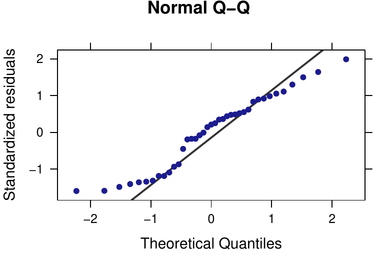

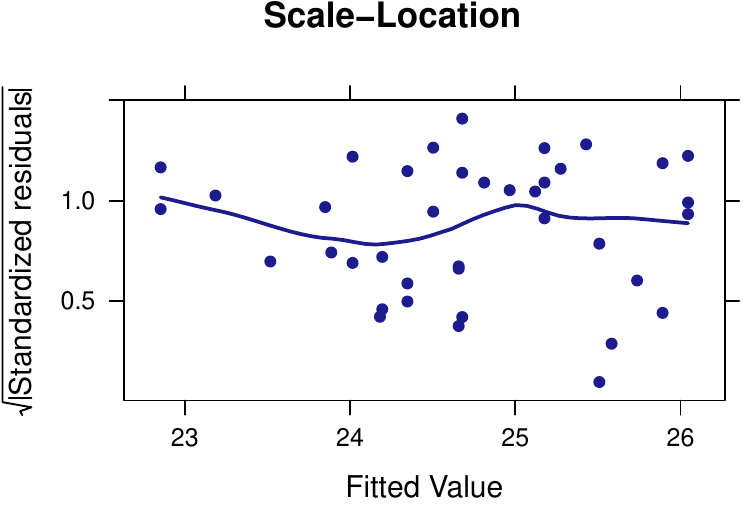

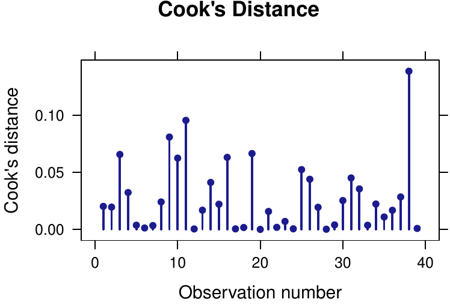

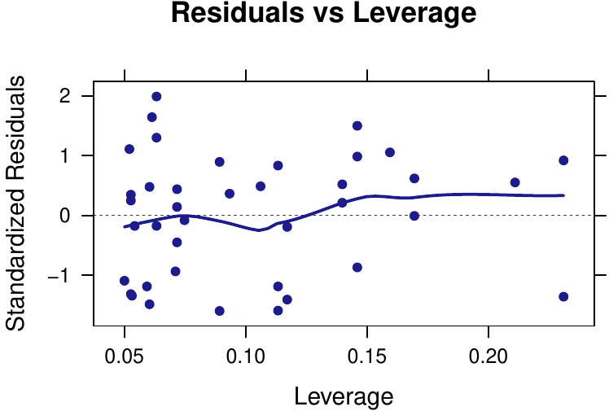

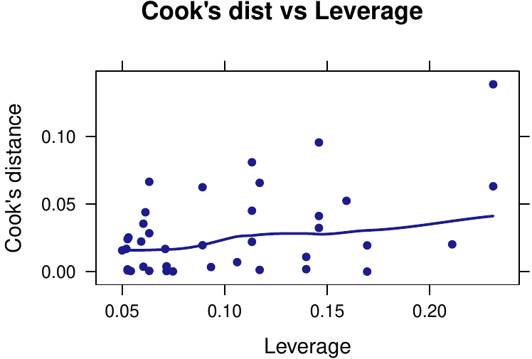

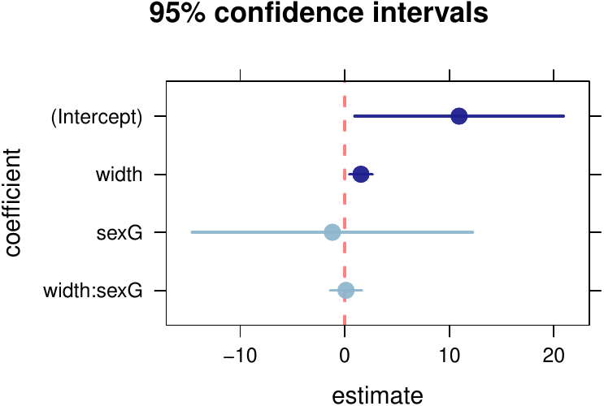

```r
mod <- lm(length ~ width * sex, data = KidsFeet)
mplot(mod, system = "lattice", which = 1:7)
```

We can also use `mplot()` to visually represent the results of `TukeyHSD()`, which has been modified so that it can be applied directly to objects produced by `lm()`.

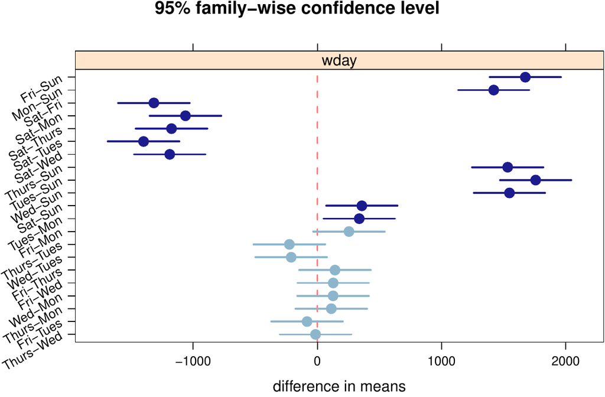

```r
mplot(TukeyHSD(lm(births ~ wday, data = Births78)), order = "pval")
```

The resulting plots are formatted in a way that makes them usable in a wider range of scenarios than are those produced using `plot()`.

A second use for `mplot()` is to create *lattice* and [*ggplot2*](https://CRAN.R-project.org/package=ggplot2) plots interactively within RStudio. Issuing the following command in RStudio will bring up a plot that can be modified by making choices in the accompanying menu.

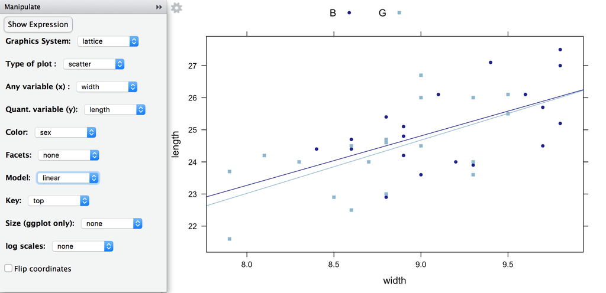

```r
mplot(KidsFeet)
```

The menu allows the user to choose either *lattice* or *ggplot2* graphics, to select the type of plot and the variables used, and to control a few of the most commonly used features that modify a plot (faceting, color, legends, log-scaling, fitting a linear model or LOESS smoother). The “Show Expression” button exports the command used to create the plot into the console. From there it can be edited or copied and pasted into an R Markdown document. This can be very useful for new users working to master the syntax for a particular graphical system.

# Randomization and resampling

Resampling approaches have become increasingly important in statistical education (N. Tintle et al. 2015; Hesterberg 2015). The *mosaic* package provides simplified functionality to support teaching inference based on randomization tests and bootstrap methods. Our goal was to focus attention on the important parts of these techniques (e.g., where randomness enters in and how to use the resulting distribution) while hiding some of the technical details involved in creating loops and accumulating values.

## A first example

As a first example, we often introduce (a version of) the story of the lady tasting tea. (See (Salsburg 2002) for the details of this famous story.) But here we will test a coin to see whether it is a “fair coin”. Suppose we flip the coin 20 times and observe only 6 heads, how suspicious should we be that the coin is not fair? The statistical punchline for either the lady tasting tea or testing a coin is that we want to compute the p-value for a binomial test via simulations rather than using formulas for the binomial distribution or normal approximations. But we want to do this on the first day of class, and without using any of the jargon of the preceding sentence.

Because students do not know about sampling distributions or random variables yet, but do understand the idea of a coin toss, we have provided `rflip()` to simulate tossing a coin one or several times:

```r
rflip()
```

```r
##
## Flipping 1 coin [ Prob(Heads) = 0.5 ] ...
##
## H
##
## Number of Heads: 1 [Proportion Heads: 1]
```

```r
rflip(20)
```

```r
##
## Flipping 20 coins [ Prob(Heads) = 0.5 ] ...
##
## H T T T H T H H H H H T T H H T T H H T
##
## Number of Heads: 11 [Proportion Heads: 0.55]
```

To test a null hypothesis of a fair coin, we need to simulate flipping 20 coins many times, recording for each simulation the number of heads that were observed. The `do()` function allows us to do just that using the following template

```r
do(n) * {stuff to do}             # pseudo-code
```

where `{stuff to do}` is typically a single R command, but may be something more complicated. We teach this syntax by reading it aloud: “Do n times …” For example, we can flip 20 coins three times as follows.

```r
do(3) * rflip(20)   # do 3 times flip 20 coins
```

```r
##    n heads tails prop
## 1 20    10    10 0.50
## 2 20     8    12 0.40
## 3 20    15     5 0.75
```

Notice that `do()` (technically `cull_for_do()`) has been clever about what information is stored for each group of 20 coin tosses and that the results are returned in a data frame.

It is now a simple matter to do this many more times and use numerical or graphical summaries to investigate how unusual it is to get so few heads if the coin is indeed a fair coin.

```r
Sims <- do (1000) * rflip(20)
histogram( ~ heads, data = Sims, width = 1, groups = heads <= 6)
tally ( ~ (heads <= 6), data = Sims)
```

```r
## (heads <= 6)
##  TRUE FALSE
##    54   946
```

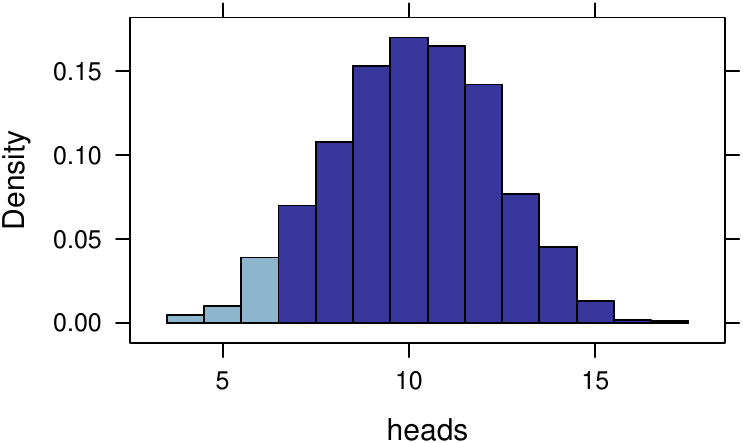

Readers familiar with *lattice* will notice that the *mosaic* package adds some additional arguments to the `histogram()` function. Among these are `width` and `center` which can be used to control the width and position of the bins and are much easier for new users to master than the `breaks` argument supplied by *lattice*.

## The `sample()`, `resample()`, and `shuffle()` functions

To facilitate randomization and bootstrapping, *mosaic* extends `sample()` to operate on data frames. The `shuffle()` function is an alternative name for `sample()`, and `resample()` is `sample()` with `replace = TRUE`. With these in hand, all of the tests and confidence intervals seen in a traditional first course in statistics can be performed using a common outline:

1. Do it to your data
2. Do it to a randomized version of your data
3. Do it to lots of randomized versions of your data.

For example, we can use randomization in place of the two-sample t test to obtain an empirical p-value.

```r
D <- diffmean(age ~ smoker, data = Whickham); D
```

```r
## diffmean
##    -4.02
```

```r
do(1) * diffmean(age ~ shuffle(smoker), data = Whickham)
```

```r
##   diffmean
## 1    -1.69
```

```r
Null.dist <- do(5000) * diffmean(age ~ shuffle(smoker), data = Whickham)
histogram( ~ diffmean, data = Null.dist, v = D, xlim = c(-5,5))
prop( ~ (diffmean < D), data = Null.dist)
```

```r
## TRUE
##    0
```

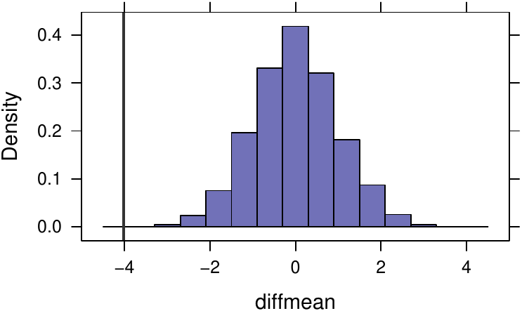

None of the 5000 replications led to a difference in means as large as the one in the original data.

It should be noted that although this is typically not done in simulation-based introductory statistics texts, one might prefer to calculate p-values by including the observed data in the randomization distribution. This avoids an empirical p-value of 0 and guarantees that the actual type I error rate will not exceed the nominal type I error rate. This amounts to adding one to the numerator and denominator. The `prop1()` function automates this for us.

```r
prop1( ~ (diffmean < D), data = Null.dist)
```

```r
##  TRUE
## 2e-04
```

```r
1/5001
```

```r
## [1] 2e-04
```

For more precise estimation of small p-values, additional replications should be used.

The example above introduces three additional *mosaic* functions. The `prop()` and `prop1()` functions compute the proportion of logical vector that is (by default) `TRUE` or of a factor that is (by default) in the first level; `diffmean()` is similar to `diff(mean())`, but labels the result differently (`diffprop()` works similarly for differences in proportions).

If we are interested in a confidence interval for the difference in group means, we can use `resample()` and `do()` to generate a bootstrap distribution in one of two ways.

```r
Boot1 <- do(1000) * diffmean(age ~ smoker, data = resample(Whickham))
Boot2 <- do(1000) * diffmean(age ~ smoker, data = resample(Whickham, groups = smoker))
```

In the second example, the resampling happens within the smoker groups so that the marginal counts for each group remain fixed. This can be especially important if one of the groups is small, because otherwise some resamples might not include any observations of that group.

```r
favstats(age ~ smoker, data = Whickham)
```

```r
##   smoker min Q1 median Q3 max mean   sd   n missing
## 1     No  18 32     48 65  84 48.7 18.8 732       0
## 2    Yes  18 32     45 57  84 44.7 15.3 582       0
```

```r
favstats(age ~ smoker, data = resample(Whickham))
```

```r
##   smoker min Q1 median Q3 max mean   sd   n missing
## 1     No  18 32     48 65  84 48.6 18.8 752       0
## 2    Yes  18 32     45 56  83 44.8 15.0 562       0
```

```r
favstats(age ~ smoker, data = resample(Whickham, groups = smoker))  # fix margins
```

```r
##   smoker min Q1 median Q3 max mean   sd   n missing
## 1     No  18 33   49.0 66  84 49.3 18.9 732       0
## 2    Yes  18 31   44.5 56  82 44.3 15.4 582       0
```

Using either bootstrap distribution, two simple confidence intervals can be computed. We typically introduce percentile confidence intervals first (but note that these can have poor performance for small sample sizes). A percentile confidence interval is calculated by determining the range of a central portion of the bootstrap distribution, which can be automated using `cdata()`. Visually inspecting the bootstrap distribution for skew and bias is an important step to make sure the percentile interval is not being applied in a situation where it may perform poorly.

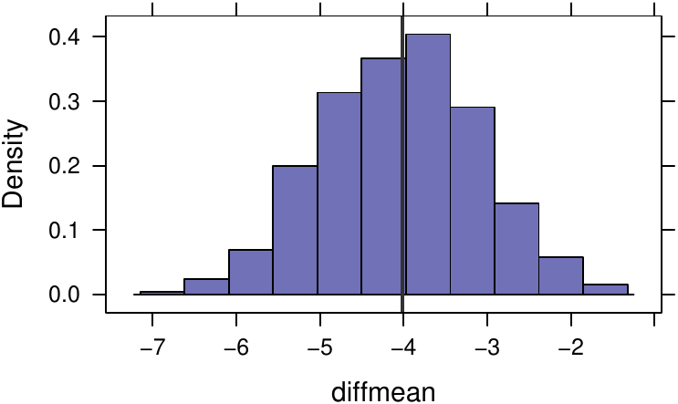

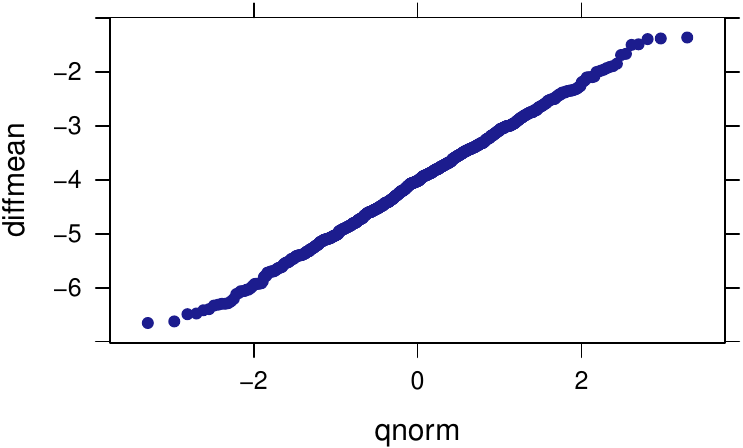

```r
histogram( ~ diffmean, data = Boot2, v = D)
qqmath( ~ diffmean, data = Boot2)
```

```r
cdata( ~ diffmean, p = 0.95, data = Boot2)
```

```r
##       low        hi central.p
##     -5.93     -2.30      0.95
```

Alternatively, we can compute a confidence interval based on a bootstrap estimate of the standard error.

```r
SE <- sd( ~ diffmean, data = Boot2); SE
```

```r
## [1] 0.941
```

```r
D + c(-1,1) * 2 * SE
```

```r
## [1] -5.90 -2.14
```

The primary pedagogical value of the bootstrap standard error approach is its close connection to the standard formula-based confidence interval methods. How to replace the constant 2 with an appropriate value to create more accurate intervals or to allow for different confidence levels is a matter of some subtlety (Hesterberg 2015). The simplest method is to use quantiles of a normal distribution, but the resulting intervals will typically undercover. Replacing the normal distribution with an appropriate t-distribution will widen intervals and can improve coverage, but the t-distribution is only correct in a few cases – such as when estimating the mean of a normal population – and can perform badly when the population is skewed.

Calculating simple confidence intervals can be further automated using an extension to `confint()`.

```r
confint(Boot2, method = c("percentile", "stderr"))
```

```r
##       name lower upper level     method estimate margin.of.error   df
## 1 diffmean -5.93  -2.3  0.95 percentile    -4.02              NA   NA
## 2 diffmean -5.89  -2.2  0.95     stderr    -4.02            1.85 1313
```

## Additional examples

One of the package vignettes (Pruim, Horton, and Kaplan 2016) contains a list of *mosaic*-related resources. Included in the list are links to companion volumes for several textbooks, including two simulation-based texts (Lock et al. 2013; Nathan Tintle et al. 2016) and several traditional textbooks (De Veaux, Velleman, and Bock 2015, 2014; Moore, McCabe, and Craig 2014; Ramsey and Schafer 2013). Each of these companion volumes demonstrates how to use R and the *mosaic* package to recreate the analyses for the examples in the text.

## Vignettes

The *mosaic* package includes several vignettes that provide additional material on using the package and on the “less volume, more creativity” approach.

A particularly useful vignette is a one-page list of commands that are more than sufficient for a first course, originally presented as part of a roundtable discussion at the Joint Statistics Meetings. (Pruim 2011)

## RMarkdown

“Thinking with data” goes hand-in-hand with communicating those thoughts. The R Markdown system provides valuable facilities for reliable and reproducible reporting of computational ideas and results. See (Baumer et al. 2014) for a discussion of how R Markdown can be used in statistics courses.

The *mosaic* package contains three templates for creating R Markdown documents in RStudio. Each ensures that the *mosaic* package is attached, sets the default theme for *lattice* graphics to `theme.mosaic()`, chooses a somewhat smaller default size for graphics, and includes a comment reminding users to attach any packages they intend to use. The “fancy” template demonstrates several features of R Markdown, and the “plain” templates allow users to start with a clean slate.

## Workarounds for unfortunate name collisions

The *mosaic* package depends on *lattice* and *ggplot2* so that plots can be made using either system whenever the *mosaic* package is attached. It also depends on [*dplyr*](https://CRAN.R-project.org/package=dplyr) (Wickham and Francois 2015), but for a different reason. The functions in *dplyr* implement a “less volume, more creativity” approach to data transformation and we encourage its use alongside *mosaic*. Unfortunately, there are several function names – most notably `do()` and `tally()` – that exist in both packages. After the release of *dplyr* we modified the functions in *mosaic* so that the two packages can coexist amicably as long as *mosaic* comes before *dplyr* in the search path.

# Discussion

## Advantages of the mosaic approach

One of the keys to successfully empowering students to think with data is providing them both a conceptual framework that allows them to know what to look for and how to interpret what they find, and a computational toolbox that allows them to do the looking. The approach made possible with the *mosaic* package simplifies the transition from thinking to computing by reducing the number of computational templates students learn so that cognitive effort can be spent elsewhere, and by having those templates reflect, support, and deepen the underlying thinking (Grolemund and Wickham 2014).

Because of the connection between conceptual understanding and these computational tools, the use of R can also help reveal misunderstandings that might otherwise go unnoticed. For example, if a student attempts to use `t.test()` or to create a histogram using a categorical variable, the student will receive error or warning messages that are an indication that either the student does not understand the current data set or still has confusion regarding what it means for a variable to be categorical or continuous and which operations are suited for each kind of variable. We encourage students to make sure they can answer two important questions before attempting to issue a command in R:

1. What do I want the computer to do for me?
2. What does it need to know in order to do that?

If these two questions can be answered clearly and correctly, then the student’s primary issue is one of creating the correct R code. If they cannot, then the problem lies elsewhere. In our experience, students who can consistently answer these two questions have relatively little trouble translating the answers into R code using the commands we teach.

R has the capability to support the increasing complexity of the data and analyses students encounter in subsequent courses and research projects. Eventually, students will need to learn more about the structure of R as a language, the types of objects it supports, and alternative ways of approaching the same task. But early on, it is more important that students can successfully and independently exercise computational and statistical creativity.

## Challenges of using R in introductory courses

Using R is not without some challenges. The first challenge is to get all of the students up and running. The use of an RStudio server allows an institution or instructor to install and configure R and its packages and students to work within a web browser, essentially eliminating the start-up costs for the students. Otherwise, instructors must assist students as they navigate installation of R and whichever additional packages are required.

Once students have access to R, the *mosaic* package reduces, but does not eliminate, the amount of syntax students need to learn. It is important to emphasize the similarity among commands within a template, to remind students that R is case sensitive, to show them how to take advantage of shortcuts like tab completion and code history navigation, and to explicitly teach students how to interpret some of the most common R error messages. This goes a long way toward smoothing the transition to a command line interface that is not as forgiving as Google search (which may be many students’ only other experience with computerized response to things they type).

In our experience, the most commonly occurring struggles for students using *mosaic* are

1. General anxiety over typing commands.

   Although students are very familiar with using computers and computerized devices like smart phones, many of them have little experience typing commands that require following syntax rules. The “less volume, more creativity" approach helps with this, by reducing the cognitive burden. But it remains important to highlight repeatedly the similarities among commands. Students should also be taught how to interpret the most common error messages R produces so that they can quickly, easily, and comfortably recover from inevitable typing errors. Even if a class does not typically meet in a computer laboratory or take advantage of student laptops, it can be useful to arrange some sessions early in the course where students are using RStudio while someone is there to quickly help them when they get stuck. Avoiding frustration in students’ early experience with R goes a long way in overcoming anxiety.

   As a bonus instructional method, the authors make frequent typing mistakes in front of the class. While we could not avoid this if we tried, it does serve to demonstrate both how to recover from errors and that nothing drastic has happened when an error message is displayed.

   One big advantage of the command line interface is that it is much easier to help students by email or in a discussion forum. Encourage students to copy both their commands and the error messages or output that were produced. Even better, have them share their work in the form of an R Markdown file. We find students are much more capable of doing this than they are of correctly describing the chain of events they initiated in a menu-driven system. (It is also much easier to give detailed instructions and examples.)
2. Confusion over the tilde (`~`).

   The tilde is a small symbol, easily overlooked on the screen or on paper (or mistaken for `-`), so students will sometimes omit it, or put it where it doesn’t belong. As a visual aid, we recommend surrounding the `~` with a space on either side, even in 1-sided formulas.

   A similar thing occurs with explicitly naming the `data` argument, which is not required for the *lattice* functions, but is for several other functions. Teaching the forms that work in all contexts is easier than teaching which contexts allow which forms.
3. Difficulty in setting up the R environment

   This is all but eliminated when using an RStudio server, but in situations where instructors prefer a local R installation for each student, there are often a few issues involved in getting all students up and running. Installation of R and RStudio is straightforward, but one should make sure that students all have the latest version of each. To use the *mosaic* package, a number of additional packages must be installed. We recommend beginning with

```r
update.packages()
```

or the equivalent operation from the RStudio “Packages” tab to make sure all packages currently on the system are up to date. In most cases,

```r
install.packages("mosaic")
```

(again, this can also be done via the “Packages” tab in RStudio) will take care of the rest. But occasionally some package will not install correctly on a particular student’s computer. Installing that package directly rather than as part of the dependencies of *mosaic* often solves this problem or at least provides a useful diagnostic regarding what the problem might be.

## Impact

In 2016, the available CRAN logs indicate that *mosaic* was downloaded to approximately 96,000 unique IP addresses. Strong peaks over January and September suggest that much of this demand comes from university courses.

## Efficiency Issues

For applications where speed is of utmost importance, the *mosaic* wrappers may not be the optimal approach. For the numerical summary functions, the *mosaic* versions cannot be faster than their counterparts in *base* or *stats* (because eventually they call the underlying functions) and may be noticeably slower in contexts where they are called many times. In particular, using the formula interface requires parsing the formula and creating a new object to contain the data described by the formula. On the other hand, for aggregated numerical summaries, the loss in performance may represent a small price to pay for the simplified syntax.

Similarly, using `do()` comes at a price, although here the increased computation time has more to do with the extra work involved in culling the objects and reformatting the results. The looping itself is as fast as using `replicate()` – indeed the underlying code is very similar – and can be faster when the [*parallel*](https://CRAN.R-project.org/package=parallel) package is attached; even on a laptop with a single quad-core processor, the speed-up is noticeable.

## Lattice vs. ggplot2

Early on, we chose to adopt *lattice* graphics because of its compatibility with the formula template. This provides a simple, consistent means of creating the plots our students need. One weakness of the *lattice* system is the difficulty of creating complex plots by overlaying mutliple simpler layers. Beginners are not in a position to create the panel (and pre-panel) functions that *lattice* requires for this. Recently, we have begun work on a new package (*ggformula*, currently avilable via github) that provides a formula interface for creating *ggplot2* plots. This package could replace *lattice* for users who desire some of the features of *ggplot2* but want to keep a consistent formula interface. Initial use with our students suggests that this works at least as well as *lattice* and much better if plots with multiple layers and data sources are required.

## Be selective

Over the years we have been developing the *mosaic* package, it has grown to the point that it now contains much more than a minimally sufficient set of commands for an introductory course. While we have attempted to give some sense of the scope of the package in this article, we advise instructors to use things selectively, keeping in mind their students and the goals for the course. What may represent just the right tool in one setting may be too much in another. Of course, the same advice holds for using functions from other packages as well. The instructor’s temptation is often to do too much, forgetting the cognitive burden this can place on students. Less volume and more creativity will at times pull in opposite directions, and a skilled instructor must determine the appropriate balance for each setting.

# Acknowledgments

Partial support for this work was provided by the National Science Foundation DUE 0920350 (Project MOSAIC). We thank Johanna Hardin, Colin Rundel, Xiaofei (Susan) Wang, and the reviewers for helpful comments and all of the users of the *mosaic* package who have provided feedback on their experience and offered suggestions for improvement.

# Appendix: Additional features of the mosaic package

Table 2 lists some additional functions in the *mosaic* package not highlighted above.

Table 2: Some additional functions in the *mosaic* package.

[output not shown]

## Handling missing data

When there are missing values, the numerical summary functions in *base* and *stats* return results that may surprise new users.

```r
mean( ~ dayslink, data = HELPmiss)
```

```r
## [1] NA
```

While there are workarounds using options to functions to drop values that are missing before performing the computation, these may be intimidating to new users.

```r
mean( ~ dayslink, data = HELPmiss, na.rm = TRUE)
```

```r
## [1] 257
```

We offer two other solutions to this situation. Our favorite is the `favstats()` function which computes a set of useful numerical summaries on the non-missing values and also reports the number of missing values.

```r
favstats( ~ dayslink, data = HELPmiss)
```

```r
##  min Q1 median  Q3 max mean  sd   n missing
##    2 75    363 365 456  257 151 447      23
```

The second solution is to change the default behavior of `na.rm` using `options()`. This will, of course, only affect the *mosaic* versions of these functions.

```r
options(na.rm = TRUE)
mean( ~ dayslink, data = HELPmiss)
```

```r
## [1] 257
```

```r
with(HELPmiss, base::mean(dayslink))
```

```r
## [1] NA
```

Users also have the option of changing the default for `na.rm` back if they like.

```r
options(na.rm = NULL)
mean( ~ dayslink, data = HELPmiss)
```

```r
## [1] NA
```

## Inspecting a data frame

Summaries of all variables in a data frame can be obtained using `inspect()`. For quantitative variables, the results of `favstats()` are displayed. Other summaries are provided for categorical and time variables.

```r
inspect(Births78)
```

```r
##
## categorical variables:
##   name   class levels   n missing                                  distribution
## 1 wday ordered      7 365       0 Sun (14.5%), Mon (14.2%), Tues (14.2%) ...
##
## quantitative variables:
##        name   class  min   Q1 median   Q3   max mean  sd   n missing
## 1    births integer 7135 8554   9218 9705 10711 9132 818 365       0
## 2 dayofyear integer    1   92    183  274   365  183 106 365       0
##
## time variables:
##   name   class      first       last min_diff max_diff   n missing
## 1 date POSIXct 1978-01-01 1978-12-31        1        1 365       0
```